# Data

The dataset has future merchant transaction activity, for merchants that start over a 2 year period (2033-2034). The data spans from 1/1/33 through 12/31/34. Although the data is made up, you can consider this to be a random sample of future merchants using Stripe. Each observation is a transaction amount in cents. If the merchant stops processing with Stripe, then they would no longer appear.

# Questions

1. Identify different kinds of businesses in the data, and generate assignments for each merchant.
2. Identify merchants that have already churned in the dataset, and build a model to predict which active merchants are most likely to churn in the near future.

# Solution

- Segments merchants into 4 types of business using RFM model with clustering technique
- Determine characteristics of different types of businesses
- Label each merchant into churned or not churned, based on whether they made a transaction after 30 days of their first transaction.
- Engineered features based on merchants' first 30 day transaction history, including number of transactions in a month (frequency), total transaction amount in a month('monetary'), the time interval between transactions, and the average trasaction hour.
- Built a random forest model to pedict churn propability, with a F1=0.43, recall=0.38, precision=0.50.

# Findings

1. Four types of merchants in the dataset.

| Cluster | Segments | RFM Characterisitcs | Action |
| --- | --- | --- | --- |
| 0 | Lost Customer | Low frequency, low spending, not making trasactions recently | Surveys to figure out why they churned to prevent further churning |
| 1 | New Customer | Made recent transactions with low frequency and transaction amount | Win their trust and convert them to loyal customers to boost their transaction frequency and amount |
| 2 | Best Customer | Frequent and recent customers, high transaction amount | Keep them happy and loyal; potential customers for new product or services |
| 3 | At risk of leaving/churned | Used to be frequent and heavy spenders, but has not transact recently. Their last transaction was 7 months ago | Figure out why they churned; customize marketing campaings to reactivate them |

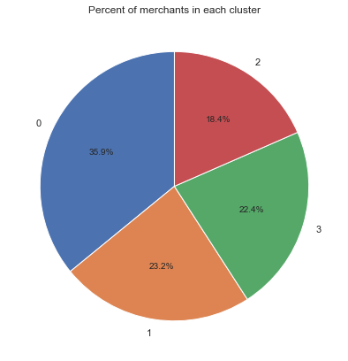

1. Monetary is our top most important feature in predicting customer churn. As monetary and frequency are highly correlated, RF treats frequency as the least important.

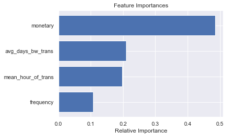

### Future work

The recall score is only slightly higher than the churn rate (0.30). In the future, we can collect more relevant features such as age of the merchant, types of businesses, etc. to help improve model performace.

```python
import numpy as np
import pandas as pd
import datetime as dt
import matplotlib.pyplot as plt
import matplotlib.mlab as mlab
import matplotlib.cm as cm
%matplotlib inline

import seaborn as sns
sns.set(style="ticks", color_codes=True, font_scale=1.0)
color = sns.color_palette()
sns.set_style('darkgrid')

from scipy import stats
from scipy.stats import skew, norm, probplot, boxcox

from sklearn.preprocessing import StandardScaler
from sklearn.cluster import KMeans
from sklearn.metrics  import silhouette_score, silhouette_samples
```

```python
df = pd.read_csv('takehome_ds_written.csv')
```

```python
df.head()
```

|  | Unnamed: 0 | merchant | time | amount_usd_in_cents |
| --- | --- | --- | --- | --- |
| 0 | 1 | faa029c6b0 | 2034-06-17 23:34:14 | 6349 |
| 1 | 2 | ed7a7d91aa | 2034-12-27 00:40:38 | 3854 |
| 2 | 3 | 5608f200cf | 2034-04-30 01:29:42 | 789 |
| 3 | 4 | 15b1a0d61e | 2034-09-16 01:06:23 | 4452 |
| 4 | 5 | 4770051790 | 2034-07-22 16:21:42 | 20203 |

```python
df.shape
```

```
(1513719, 4)
```

```python
df.info()
```

```
<class 'pandas.core.frame.DataFrame'>
RangeIndex: 1513719 entries, 0 to 1513718
Data columns (total 4 columns):
 #   Column               Non-Null Count    Dtype
---  ------               --------------    -----
 0   Unnamed: 0           1513719 non-null  int64
 1   merchant             1513719 non-null  object
 2   time                 1513719 non-null  object
 3   amount_usd_in_cents  1513719 non-null  int64
dtypes: int64(2), object(2)
memory usage: 46.2+ MB
```

```python
df.nunique()
```

```
Unnamed: 0             1513719
merchant                 14351
time                   1479950
amount_usd_in_cents      94094
dtype: int64
```

```python
df.describe()
```

|  | Unnamed: 0 | amount_usd_in_cents |
| --- | --- | --- |
| count | 1.513719e+06 | 1.513719e+06 |
| mean | 7.568600e+05 | 1.548466e+04 |
| std | 4.369732e+05 | 6.161886e+04 |
| min | 1.000000e+00 | 2.010000e+02 |
| 25% | 3.784305e+05 | 3.215000e+03 |
| 50% | 7.568600e+05 | 6.104000e+03 |
| 75% | 1.135290e+06 | 1.260600e+04 |
| max | 1.513719e+06 | 2.592028e+07 |

```python
# cehck duplicates
df.duplicated().any()
```

```
False
```

```python
# check nulls
df.isnull().any()
```

```
Unnamed: 0             False
merchant               False
time                   False
amount_usd_in_cents    False
dtype: bool
```

```python
df.drop(columns=['Unnamed: 0'], inplace=True)
```

```python
df['time'] = pd.to_datetime(df['time'])
```

```python
# check date min and max
print(df['time'].min())
print(df['time'].max())
```

```
2033-01-01 09:38:32
2034-12-31 07:59:40
```

```python
# Create some columns for explore
df['date'] = df.time.apply(lambda x: x.date())
df['weekday'] = df.time.apply(lambda x: x.weekday())
df['weekday_name'] = df.time.apply(lambda x: x.strftime("%A"))
df['hour'] = df.time.apply(lambda x: x.hour)
```

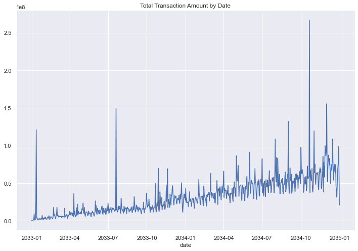

```python
# daily transaction amount
plt.figure(figsize=(12,8))
df.groupby('date')['amount_usd_in_cents'].sum().plot()
plt.title('Total Transaction Amount by Date')
plt.show()
```

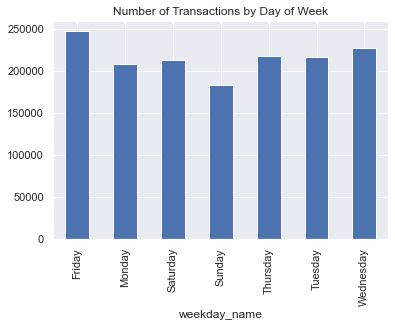

```python
# count the number of transactions
df.groupby('weekday_name')['amount_usd_in_cents'].count().plot.bar()
plt.title('Number of Transactions by Day of Week')
plt.show()
```

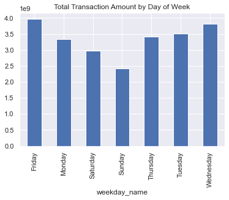

```python
df.groupby('weekday_name')['amount_usd_in_cents'].sum().plot.bar()
plt.title('Total Transaction Amount by Day of Week')
plt.show()
```

Most merchants use on Friday. Merchants use Stripe the least on Sunday

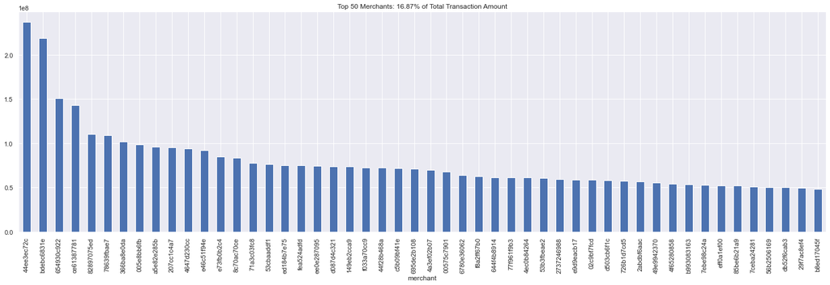

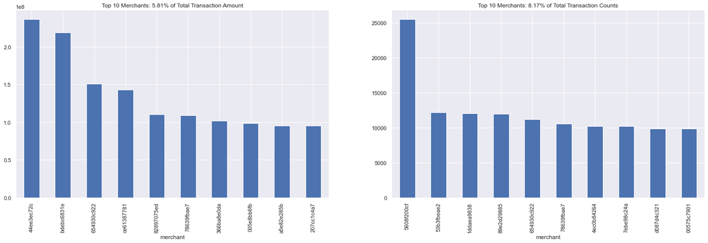

```python
# plot top 50 and top 10 merchants

#get the total transaction amount of top 50 merchants
df.groupby('merchant').amount_usd_in_cents.sum().sort_values(ascending=False).head(50).sum()\

#calculate their contribution to all transaction amount
percent_transaction_amount = df.groupby('merchant').amount_usd_in_cents.sum().sort_values(ascending=False).head(50).sum()\
               /df.amount_usd_in_cents.sum()*100

#plot top 50 merchants on their transaction amount
fig = plt.figure(figsize=(25, 7))
df.groupby('merchant').amount_usd_in_cents.sum().sort_values(ascending=False).head(50).plot(kind='bar',
                                                                                       title='Top 50 Merchants: {:3.2f}% of Total Transaction Amount'.format(percent_transaction_amount))
#plot top 10 merchants on how much they transact
fig = plt.figure(figsize=(25, 7))
f1 = fig.add_subplot(121)
percent_transaction_amount = df.groupby('merchant').amount_usd_in_cents.sum().sort_values(ascending=False).head(10).sum()\
                /df.amount_usd_in_cents.sum()*100
df.groupby('merchant').amount_usd_in_cents.sum().sort_values(ascending=False).head(10).plot(kind='bar',
                                                                                       title='Top 10 Merchants: {:3.2f}% of Total Transaction Amount'.format(percent_transaction_amount))
#plot top 10 customers on how ofen they buy
f1 = fig.add_subplot(122)
percent_transaction = df.groupby('merchant').amount_usd_in_cents.count().sort_values(ascending=False).head(10).sum()\
                     /df.amount_usd_in_cents.count()*100
df.groupby('merchant').amount_usd_in_cents.count().sort_values(ascending=False).head(10).plot(kind='bar',
                                                                                        title='Top 10 Merchants: {:3.2f}% of Total Transaction Counts'.format(percent_transaction))
```

Merchants who transact most frequently are not necessarily those who transact the largest amount

# RFM User Segmentation

### Recency: days since last transaction

the smaller, the better

```python
# The data is from 2033-01-01 to 2034-12-31
# I take 2035-01-01 as referece date
reference_date = df.date.max()+ dt.timedelta(days=1)
reference_date
```

```
datetime.date(2035, 1, 1)
```

```python
# calulcate recency
df['recency'] = (reference_date - df.date).astype('timedelta64[D]')
```

```python
# keep only the lastest recency
merchant_history_df = df[['merchant','recency']].groupby('merchant').min().reset_index()
merchant_history_df.head()
```

|  | merchant | recency |
| --- | --- | --- |
| 0 | 0002b63b92 | 595.0 |
| 1 | 0002d07bba | 17.0 |
| 2 | 00057d4302 | 515.0 |
| 3 | 000bcff341 | 510.0 |
| 4 | 000ddbf0ca | 578.0 |

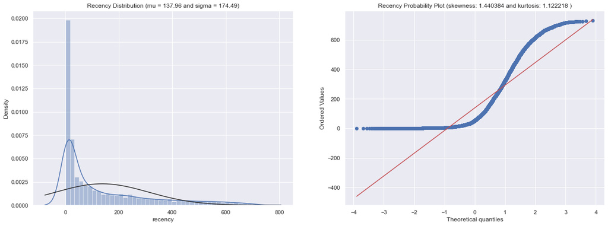

```python
# plot the KDE to get the shape of distrition of recency
# create a function of KDE and QQ plot to make it easier to plot other features
def QQ_plot(data, feature):

    #Get the fitted parameters used by the function
    (mu, sigma) = norm.fit(data)

    #KDE
    fig = plt.figure(figsize=(20,7))
    fig1 = fig.add_subplot(121)
    sns.distplot(data,fit=stats.norm, kde_kws = {'label':'KDE'}, fit_kws = {'label':'Fitted PDF'})
    fig1.set_title(feature+ ' Distribution (mu = {:.2f} and sigma = {:.2f})'.format(mu, sigma), loc='center')

    #QQ plot
    import pylab
    fig2 = fig.add_subplot(122)
    stats.probplot(data, dist="norm", plot=pylab)
    fig2.set_title(feature+ ' Probability Plot (skewness: {:.6f} and kurtosis: {:.6f} )'.format(data.skew(),data.kurt()), loc='center')
    pylab.show()

QQ_plot(merchant_history_df.recency,'Recency')
```

The plots shows the distribution of recency is right skewed. Meaning the mode of merchants are active and transact quite recently. The long right tail indicats some merchants are less active, or even churned

### Frequency: total number of purchases

```python
frequency = df.groupby(['merchant'])['merchant'].count().reset_index(name='frequency')
frequency.head()
```

|  | merchant | frequency |
| --- | --- | --- |
| 0 | 0002b63b92 | 1 |
| 1 | 0002d07bba | 4 |
| 2 | 00057d4302 | 28 |
| 3 | 000bcff341 | 1 |
| 4 | 000ddbf0ca | 1 |

```python
merchant_history_df = merchant_history_df.merge(frequency)
merchant_history_df.head()
```

|  | merchant | recency | frequency |
| --- | --- | --- | --- |
| 0 | 0002b63b92 | 595.0 | 1 |
| 1 | 0002d07bba | 17.0 | 4 |
| 2 | 00057d4302 | 515.0 | 28 |
| 3 | 000bcff341 | 510.0 | 1 |
| 4 | 000ddbf0ca | 578.0 | 1 |

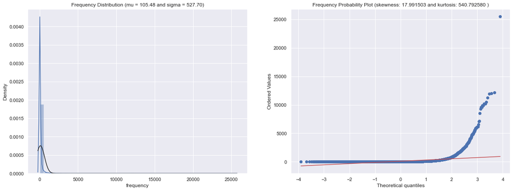

```python
QQ_plot(merchant_history_df.frequency,'Frequency')
```

### Monetary Value: total money this customer spent

```python
monetary = df[['merchant','amount_usd_in_cents']].groupby('merchant').sum().reset_index()
monetary.rename(columns={'amount_usd_in_cents':'monetary'},inplace = True)
monetary.head()
```

|  | merchant | monetary |
| --- | --- | --- |
| 0 | 0002b63b92 | 3379 |
| 1 | 0002d07bba | 89278 |
| 2 | 00057d4302 | 29521 |
| 3 | 000bcff341 | 7826 |
| 4 | 000ddbf0ca | 10299 |

```python
merchant_history_df = merchant_history_df.merge(monetary)
merchant_history_df.head()
```

|  | merchant | recency | frequency | monetary |
| --- | --- | --- | --- | --- |
| 0 | 0002b63b92 | 595.0 | 1 | 3379 |
| 1 | 0002d07bba | 17.0 | 4 | 89278 |
| 2 | 00057d4302 | 515.0 | 28 | 29521 |
| 3 | 000bcff341 | 510.0 | 1 | 7826 |
| 4 | 000ddbf0ca | 578.0 | 1 | 10299 |

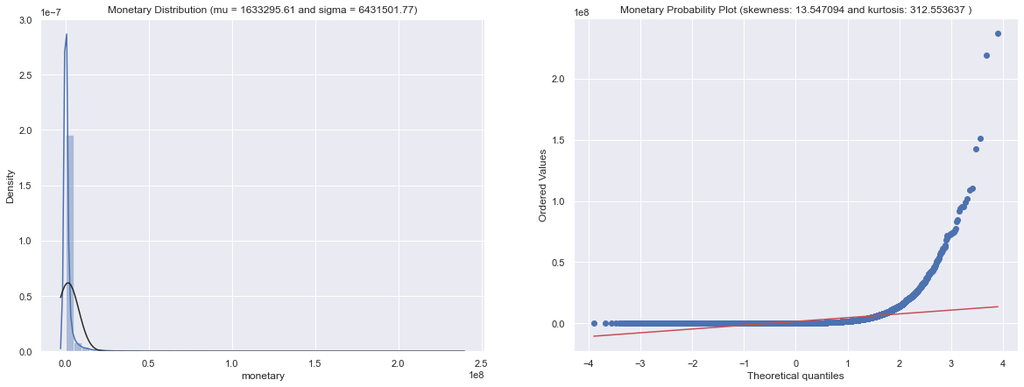

```python
QQ_plot(merchant_history_df.monetary,'Monetary')
```

```python
merchant_history_df.describe().transpose()
```

|  | count | mean | std | min | 25% | 50% | 75% | max |
| --- | --- | --- | --- | --- | --- | --- | --- | --- |
| recency | 14351.0 | 1.379616e+02 | 1.744986e+02 | 1.0 | 11.0 | 52.0 | 214.0 | 729.0 |
| frequency | 14351.0 | 1.054783e+02 | 5.277180e+02 | 1.0 | 3.0 | 11.0 | 45.0 | 25512.0 |
| monetary | 14351.0 | 1.633296e+06 | 6.431726e+06 | 201.0 | 36263.0 | 160262.0 | 823099.5 | 236907231.0 |

### RFM Score

Best customers are low recency, high frequency, and high monetary value

```python
rfm_table = merchant_history_df
rfm_table.head()
```

|  | merchant | recency | frequency | monetary |
| --- | --- | --- | --- | --- |
| 0 | 0002b63b92 | 595.0 | 1 | 3379 |
| 1 | 0002d07bba | 17.0 | 4 | 89278 |
| 2 | 00057d4302 | 515.0 | 28 | 29521 |
| 3 | 000bcff341 | 510.0 | 1 | 7826 |
| 4 | 000ddbf0ca | 578.0 | 1 | 10299 |

```python
# lable the largest percentile with the smallest number
rfm_table['R_Quartiles']=pd.qcut(rfm_table['recency'],4,labels= np.arange(1,5,1))
rfm_table['F_Quartiles']=pd.qcut(rfm_table['frequency'].rank(method='first'),4,labels=np.arange(4,0,-1))
rfm_table['M_Quartiles']=pd.qcut(rfm_table['monetary'].rank(method='first'),4,labels=np.arange(4,0,-1))
```

```python
rfm_table.head()
```

|  | merchant | recency | frequency | monetary | R_Quartiles | F_Quartiles | M_Quartiles |
| --- | --- | --- | --- | --- | --- | --- | --- |
| 0 | 0002b63b92 | 595.0 | 1 | 3379 | 4 | 4 | 4 |
| 1 | 0002d07bba | 17.0 | 4 | 89278 | 2 | 3 | 3 |
| 2 | 00057d4302 | 515.0 | 28 | 29521 | 4 | 2 | 4 |
| 3 | 000bcff341 | 510.0 | 1 | 7826 | 4 | 4 | 4 |
| 4 | 000ddbf0ca | 578.0 | 1 | 10299 | 4 | 4 | 4 |

```python
# RFM score = 100*R_Quartiles +10*F_Quartiles + M_Quartiles: the lower the better!

#categorical variables cannot do calculations, so I convert them to str

rfm_table['RFMScore'] = rfm_table.R_Quartiles.astype(str) \
                      + rfm_table.F_Quartiles.astype(str) \
                      + rfm_table.M_Quartiles.astype(str)
rfm_table.head()
```

|  | merchant | recency | frequency | monetary | R_Quartiles | F_Quartiles | M_Quartiles | RFMScore |
| --- | --- | --- | --- | --- | --- | --- | --- | --- |
| 0 | 0002b63b92 | 595.0 | 1 | 3379 | 4 | 4 | 4 | 444 |
| 1 | 0002d07bba | 17.0 | 4 | 89278 | 2 | 3 | 3 | 233 |
| 2 | 00057d4302 | 515.0 | 28 | 29521 | 4 | 2 | 4 | 424 |
| 3 | 000bcff341 | 510.0 | 1 | 7826 | 4 | 4 | 4 | 444 |
| 4 | 000ddbf0ca | 578.0 | 1 | 10299 | 4 | 4 | 4 | 444 |

```python
# select the best merchants
rfm_table[rfm_table['RFMScore']=='111'].sort_values(by='frequency',ascending=False).head(10)
```

|  | merchant | recency | frequency | monetary | R_Quartiles | F_Quartiles | M_Quartiles | RFMScore |
| --- | --- | --- | --- | --- | --- | --- | --- | --- |
| 4806 | 5608f200cf | 1.0 | 25512 | 20911571 | 1 | 1 | 1 | 111 |
| 4694 | 53b3fbeae2 | 1.0 | 12178 | 60733740 | 1 | 1 | 1 | 111 |
| 1673 | 1ddaea9838 | 1.0 | 12042 | 41443545 | 1 | 1 | 1 | 111 |
| 7713 | 89e2d29885 | 1.0 | 11969 | 18054500 | 1 | 1 | 1 | 111 |
| 5618 | 654930c922 | 2.0 | 11222 | 151116295 | 1 | 1 | 1 | 111 |
| 6713 | 78639fbae7 | 1.0 | 10527 | 108921162 | 1 | 1 | 1 | 111 |
| 4405 | 4ec0b84264 | 8.0 | 10213 | 61310767 | 1 | 1 | 1 | 111 |
| 11644 | d087d4c321 | 1.0 | 9868 | 73440729 | 1 | 1 | 1 | 111 |
| 19 | 00575c7901 | 1.0 | 9860 | 67935727 | 1 | 1 | 1 | 111 |
| 3930 | 4647d230cc | 1.0 | 9607 | 94170894 | 1 | 1 | 1 | 111 |

# K-Means Clustering

```python
# R,F,M are highly skwed, and K means is distance based algorithm, so I will log transform and standard scaler
#log transform
merchant_history_df['recency_log'] = np.log(merchant_history_df['recency'])
merchant_history_df['frequency_log'] = np.log(merchant_history_df['frequency'])
merchant_history_df['monetary_log'] = np.log(merchant_history_df['monetary'])
merchant_history_df.describe()

#scale
feature_vector = ['monetary_log', 'recency_log','frequency_log']
X_subset = merchant_history_df[feature_vector]
scaler = StandardScaler().fit(X_subset)
X_scaled = scaler.transform(X_subset)
pd.DataFrame(X_scaled, columns=X_subset.columns).describe().T
```

|  | count | mean | std | min | 25% | 50% | 75% | max |
| --- | --- | --- | --- | --- | --- | --- | --- | --- |
| monetary_log | 14351.0 | -5.967091e-16 | 1.000035 | -3.181708 | -0.752926 | -0.058214 | 0.706742 | 3.353893 |
| recency_log | 14351.0 | 3.618765e-16 | 1.000035 | -2.006711 | -0.718376 | 0.116202 | 0.876306 | 1.534845 |
| frequency_log | 14351.0 | 6.328991e-17 | 1.000035 | -1.406801 | -0.810953 | -0.106269 | 0.657796 | 4.096516 |

```python
X_scaled_df = pd.DataFrame(X_scaled, columns=X_subset.columns)
X_scaled_df.head()
```

|  | monetary_log | recency_log | frequency_log |
| --- | --- | --- | --- |
| 0 | -1.862407 | 1.425718 | -1.406801 |
| 1 | -0.331727 | -0.484490 | -0.654925 |
| 2 | -0.849089 | 1.348138 | 0.400467 |
| 3 | -1.469766 | 1.342896 | -1.406801 |
| 4 | -1.341393 | 1.410143 | -1.406801 |

```python
def elbow (X, min_k, max_k):
    X = np.array(X).reshape(-1, 1)
    elbow = {}
    for k in np.arange(min_k, max_k):
        model = KMeans (n_clusters = k, max_iter = 1000)
        k_means = model.fit(X)
        elbow[k] = k_means.inertia_

    fig, ax = plt.subplots(1,1, figsize = (8,8))
    ax.plot(list(elbow.keys()), list(elbow.values()), marker = 'o', ms = 10, mec = 'dimgray', lw = 4)
    ax.set_xlabel ('\n K values', fontsize = 20)
    ax.set_ylabel ('Sum of Squared Error\n', fontsize = 20)
    ax.set_title('\nElbow Method for determining K\n', fontsize = 20)
    ax.tick_params(labelsize = 18)
    plt.show()
```

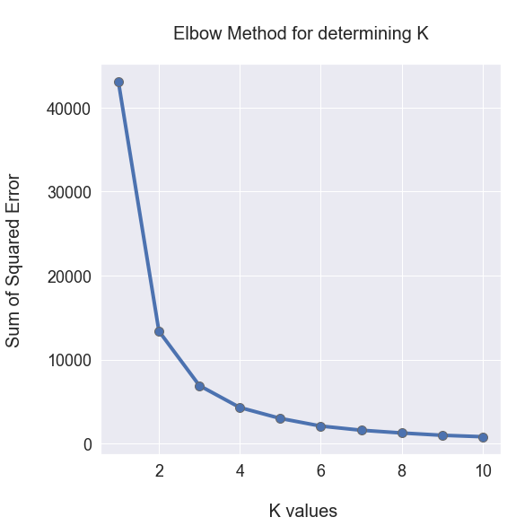

```python
elbow(X_scaled, 1, 11)
```

k = 4 or 5 appears to be optimum

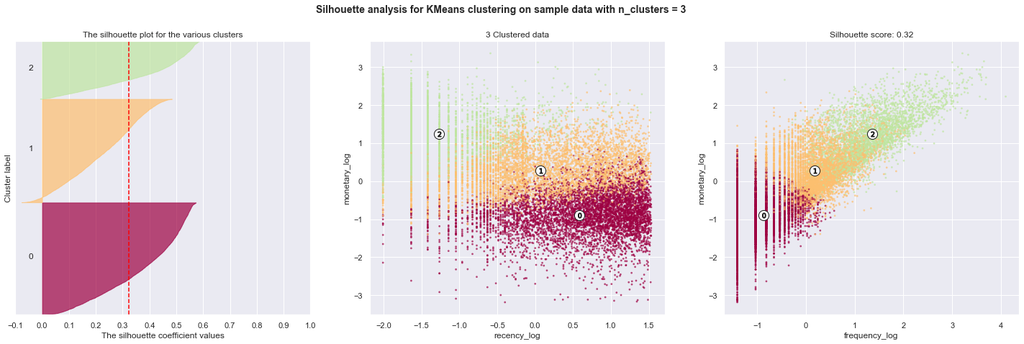

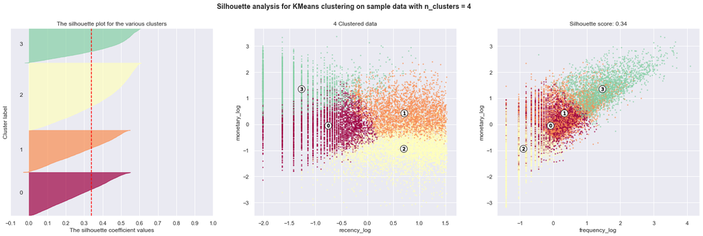

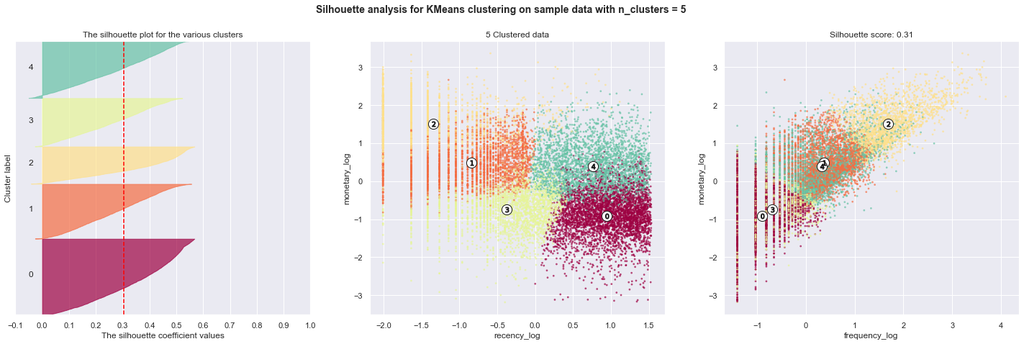

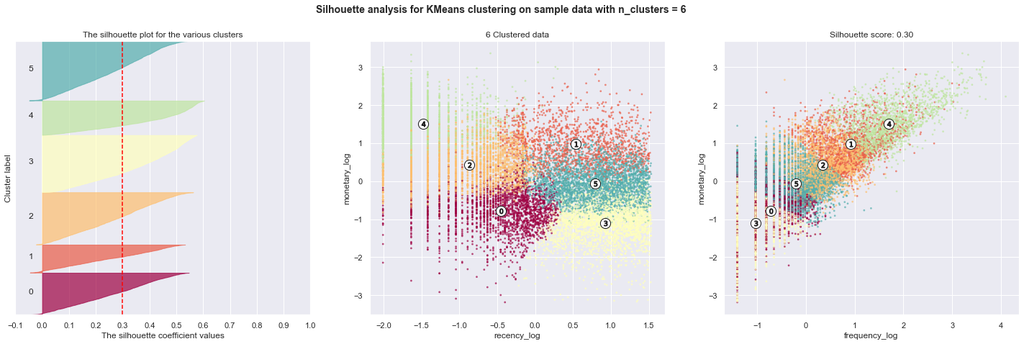

```python
cluster_centers = dict()

for n_clusters in range(3,7):
    fig, (ax1, ax2, ax3) = plt.subplots(1, 3)
    fig.set_size_inches(25, 7)
    ax1.set_xlim([-0.1, 1])
    ax1.set_ylim([0, len(X_scaled) + (n_clusters + 1) * 10])

    clusterer = KMeans(n_clusters=n_clusters, init='k-means++', n_init=10,max_iter=300, tol=1e-04, random_state=101)
    cluster_labels = clusterer.fit_predict(X_scaled)

    silhouette_avg = silhouette_score(X = X_scaled, labels = cluster_labels)
    cluster_centers.update({n_clusters :{'cluster_center':clusterer.cluster_centers_,
                                         'silhouette_score':silhouette_avg,
                                         'labels':cluster_labels}
                           })

    sample_silhouette_values = silhouette_samples(X = X_scaled, labels = cluster_labels)
    y_lower = 10
    for i in range(n_clusters):
        ith_cluster_silhouette_values = sample_silhouette_values[cluster_labels == i]

        ith_cluster_silhouette_values.sort()

        size_cluster_i = ith_cluster_silhouette_values.shape[0]
        y_upper = y_lower + size_cluster_i

        color = cm.Spectral(float(i) / n_clusters)
        ax1.fill_betweenx(np.arange(y_lower, y_upper),
                          0, ith_cluster_silhouette_values,
                          facecolor=color, edgecolor=color, alpha=0.7)

        ax1.text(-0.05, y_lower + 0.5 * size_cluster_i, str(i))
        y_lower = y_upper + 10  # 10 for the 0 samples

    ax1.set_title("The silhouette plot for the various clusters")
    ax1.set_xlabel("The silhouette coefficient values")
    ax1.set_ylabel("Cluster label")
    ax1.axvline(x=silhouette_avg, color="red", linestyle="--")
    ax1.set_yticks([])
    ax1.set_xticks([-0.1, 0, 0.1, 0.2, 0.3, 0.4, 0.5, 0.6, 0.7, 0.8, 0.9, 1])
    colors = cm.Spectral(cluster_labels.astype(float) / n_clusters)

    centers = clusterer.cluster_centers_
    y = 0
    x = 1
    ax2.scatter(X_scaled[:, x], X_scaled[:, y], marker='.', s=30, lw=0, alpha=0.7, c=colors, edgecolor='k')
    ax2.scatter(centers[:, x], centers[:, y], marker='o', c="white", alpha=1, s=200, edgecolor='k')
    for i, c in enumerate(centers):
        ax2.scatter(c[x], c[y], marker='$%d$' % i, alpha=1, s=50, edgecolor='k')
    ax2.set_title("{} Clustered data".format(n_clusters))
    ax2.set_xlabel(feature_vector[x])
    ax2.set_ylabel(feature_vector[y])

    x = 2
    ax3.scatter(X_scaled[:, x], X_scaled[:, y], marker='.', s=30, lw=0, alpha=0.7, c=colors, edgecolor='k')
    ax3.scatter(centers[:, x], centers[:, y], marker='o', c="white", alpha=1, s=200, edgecolor='k')
    for i, c in enumerate(centers):
        ax3.scatter(c[x], c[y], marker='$%d$' % i, alpha=1, s=50, edgecolor='k')
    ax3.set_title("Silhouette score: {:1.2f}".format(cluster_centers[n_clusters]['silhouette_score']))
    ax3.set_xlabel(feature_vector[x])
    ax3.set_ylabel(feature_vector[y])

    plt.suptitle(("Silhouette analysis for KMeans clustering on sample data with n_clusters = %d" % n_clusters),
                 fontsize=14, fontweight='bold')
    plt.show()
```

Cluser = 4 is the best cluster, as silhouette coefficient is the highest, meaning the clusters are dense and nicely separated compared to other clusters. The size of each cluster is also consistent.

```python
kmeans = KMeans(n_clusters = 4,random_state=1)

kmeans.fit(X_scaled)

cluster_labels = kmeans.labels_
```

```python
merchant_history_df = merchant_history_df.assign(Cluster = cluster_labels)
```

```python
merchant_history_df.head()
```

|  | merchant | recency | frequency | monetary | R_Quartiles | F_Quartiles | M_Quartiles | RFMScore | recency_log | frequency_log | monetary_log | Cluster |
| --- | --- | --- | --- | --- | --- | --- | --- | --- | --- | --- | --- | --- |
| 0 | 0002b63b92 | 595.0 | 1 | 3379 | 4 | 4 | 4 | 444 | 6.388561 | 0.000000 | 8.125335 | 0 |
| 1 | 0002d07bba | 17.0 | 4 | 89278 | 2 | 3 | 3 | 233 | 2.833213 | 1.386294 | 11.399510 | 1 |
| 2 | 00057d4302 | 515.0 | 28 | 29521 | 4 | 2 | 4 | 424 | 6.244167 | 3.332205 | 10.292857 | 3 |
| 3 | 000bcff341 | 510.0 | 1 | 7826 | 4 | 4 | 4 | 444 | 6.234411 | 0.000000 | 8.965207 | 0 |
| 4 | 000ddbf0ca | 578.0 | 1 | 10299 | 4 | 4 | 4 | 444 | 6.359574 | 0.000000 | 9.239802 | 0 |

```python
print(merchant_history_df.groupby('Cluster').agg({
    'recency':'mean',
    'frequency':'mean',
    'monetary':'mean'}) )
```

```
            recency   frequency      monetary
Cluster
0        233.215839    3.498835  4.560885e+04
1         14.924738   17.583808  3.299167e+05
2          8.783529  484.930487  7.102277e+06
3        219.252409   47.696612  1.027184e+06
```

Interpret

The 1st cluster is new customers, they are recent users with low frequency and transaction amount. Need to win their trust and convert them to loyal customers to boost their transaction frequency and amount.

The 3rd cluster is our at risk/hybernating customers. They were frequent and heavy spenders, but has been some time since last transaction. Need to figure out why they churned and how to prevent them from churning.

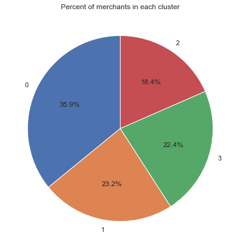

```python
fig = plt.figure(figsize=(20,7))
market = merchant_history_df.Cluster.value_counts()
plt.pie(market, labels=market.index, autopct='%1.1f%%', startangle=90)
plt.title('Percent of merchants in each cluster')
plt.show()
```

# Churn Analysis

### 1. Definition of Churn

A merchant has churned if they do not make a transaction after 30 days of their first transaction.

```python
churn_df = df.copy()
```

```python
churn_df.drop(columns='recency',inplace=True)
```

```python
first_trans = churn_df.groupby('merchant')['time'].min().reset_index(name='min_trans_date')
first_trans.head()
```

|  | merchant | min_trans_date |
| --- | --- | --- |
| 0 | 0002b63b92 | 2033-05-16 20:07:57 |
| 1 | 0002d07bba | 2034-10-11 17:02:26 |
| 2 | 00057d4302 | 2033-05-30 01:30:52 |
| 3 | 000bcff341 | 2033-08-09 20:18:36 |
| 4 | 000ddbf0ca | 2033-06-02 13:25:12 |

```python
churn_df = churn_df.merge(first_trans)
```

```python
churn_df['age'] = (churn_df['time'] - churn_df['min_trans_date']).astype('timedelta64[D]')
```

```python
# merchants that still make another transactions after 30 days
not_churned_merchants = set(churn_df[churn_df['age']>30].merchant.values)
print('number of merchants that make transactions after 30 days of their first transaction: ', len(not_churned_merchants))
```

```
number of merchants that make transactions after 30 days of their first transaction:  9997
```

```python
# keep only 30 day record for each merchant
churn_df = churn_df[churn_df['age']<=30]
```

```python
def churn(merchant):
    if merchant not in not_churned_merchants:
        return 1
    else:
        return 0
```

```python
# label target variable
churn_df['churn'] = churn_df.merchant.apply(churn)
```

### 2. Feature Engineering

```python
# create monthly frequency and monthly total transaction amount

churn = churn_df.groupby('merchant').agg({'merchant':'count',
                                        'amount_usd_in_cents':'sum'})
churn.columns = ['frequency','monetary']
churn.reset_index(inplace=True)
```

```python
# merge with target variable
churn = churn.merge(churn_df.groupby('merchant')['churn'].min().reset_index())
```

```python
# calcuate average days between transactions

# sort by date
churn_df = churn_df.sort_values(by='date')

# get previous transaction date
churn_df['previous_trans'] = churn_df.groupby('merchant')['date'].shift()

# days between transactions
churn_df['days_bw_trans'] = churn_df['date'] - churn_df['previous_trans']

# convert the date delta object to days
churn_df['days_bw_trans'] = churn_df['days_bw_trans'].apply(lambda x: x.days)

# average days between transactions
avg_days_bw_trans = churn_df.groupby('merchant')['days_bw_trans'].mean().reset_index(name='avg_days_bw_trans')

# merge
churn = churn.merge(avg_days_bw_trans)

# replace Nan (those with only 1 transaction) with 31
churn['avg_days_bw_trans'].fillna(value=31, inplace=True)
```

```python
# create the average hour of transaction per merchant
mean_hour = churn_df.groupby('merchant')['hour'].mean().reset_index(name='mean_hour_of_trans')
churn = churn.merge(mean_hour)
```

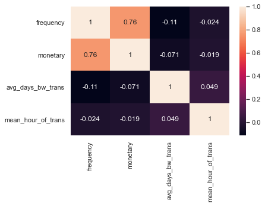

```python
# correlations between all the features
corr = churn[['frequency', 'monetary', 'avg_days_bw_trans',
       'mean_hour_of_trans']].corr()

# show heapmap of correlations
sns.heatmap(corr,annot = True)
```

frequency and transaction amount is highly correlated

```python
# Get target variable
y = churn['churn']

# check the propotion of y = 1
print('churn rate' + str(y.sum() / y.shape * 100))
```

```
churn rate[30.33934917]
```

```python
X = churn.drop(['merchant','churn'], axis=1)
X.head()
```

|  | frequency | monetary | avg_days_bw_trans | mean_hour_of_trans |
| --- | --- | --- | --- | --- |
| 0 | 1 | 3379 | 31.0 | 20.000000 |
| 1 | 2 | 43379 | 6.0 | 17.000000 |
| 2 | 17 | 20386 | 0.0 | 2.647059 |
| 3 | 1 | 7826 | 31.0 | 20.000000 |
| 4 | 1 | 10299 | 31.0 | 13.000000 |

### 3. Model Training and Result Evaluation

```python
# Splite data into training and testing
from sklearn import model_selection

# Reserve 20% for testing
X_train, X_test, y_train, y_test = model_selection.train_test_split(X, y, test_size=0.2)

print('training data has ' + str(X_train.shape[0]) + ' observation with ' + str(X_train.shape[1]) + ' features')
print('test data has ' + str(X_test.shape[0]) + ' observation with ' + str(X_test.shape[1]) + ' features')
```

```
training data has 11480 observation with 4 features
test data has 2871 observation with 4 features
```

```python
# Scale the data, using standardization
from sklearn.preprocessing import StandardScaler
scaler = StandardScaler()
X_train = scaler.fit_transform(X_train)
X_test = scaler.transform(X_test)
```

```python
# build models
from sklearn.ensemble import RandomForestClassifier, GradientBoostingClassifier
from sklearn.linear_model import LogisticRegression


# Logistic Regression
# remember that the classes are imbalanced, so we'll weight them
classifier_logistic = LogisticRegression(class_weight='balanced')

# Random Forest
classifier_RF = RandomForestClassifier(class_weight='balanced')

# Gradient Boosting
classifier_GBT = GradientBoostingClassifier()
```

```python
# Use 5-fold Cross Validation to get the AUC for different models
metrics = ['precision','recall','f1','roc_auc']
model_names = ['Logistic Regression','Random Forest','Gradient Boosting']
model_list = [classifier_logistic, classifier_RF, classifier_GBT]
count = 0

for classifier in model_list:
    cv_results = model_selection.cross_validate(classifier, X_train, y_train, cv=5,scoring=metrics)
    cv_means = {k: np.mean(v) for k,v in cv_results.items()}
    print(model_names[count])
    for k, v in cv_means.items():
        print(k, v)
    print('---')
    count += 1
```

```
Logistic Regression
fit_time 0.008679008483886719
score_time 0.003619956970214844
test_precision 0.35369509157541695
test_recall 0.44449640287769776
test_f1 0.39381219947711366
test_roc_auc 0.5355644742761865
---
Random Forest
fit_time 0.8912771224975586
score_time 0.07181510925292969
test_precision 0.48256636355662996
test_recall 0.3631381791118829
test_f1 0.4143753756387493
test_roc_auc 0.6673375630944877
---
Gradient Boosting
fit_time 0.5909116744995118
score_time 0.008284711837768554
test_precision 0.5716642923716121
test_recall 0.23778714959067226
test_f1 0.3354698837719684
test_roc_auc 0.732508757501365
---
```

Recall is important, as we want to identify those that will churn in the future. Logistic Regression has the best recall score.

On the other hand, precision is also important, as we don't want to spend resources on those merchants that have no tendency to churn. Gradient Boosting has the best precision score.

Overall, Random Forest has the best F1 score. I will chose RF as my final model, as it achieves a good balance of recall and precision score.

```python
# evaluate on test set
from sklearn import metrics
# fit the RF model with data
classifier_RF.fit(X_train, y_train)
pred = classifier_RF.predict(X_test)

# model evaluation
print("F1 score:",metrics.f1_score(y_test, pred))
print("Precision:",metrics.precision_score(y_test, pred))
print("Recall:",metrics.recall_score(y_test, pred))

y_pred_proba = classifier_RF.predict_proba(X_test)[::,1]
print("ROC score:",metrics.roc_auc_score(y_test, y_pred_proba))
```

```
F1 score: 0.4285714285714286
Precision: 0.49698795180722893
Recall: 0.3767123287671233
ROC score: 0.6846225151920898
```

```python
importances = classifier_RF.feature_importances_

# Print the feature ranking
print("Feature importance ranking by Random Forest Model:")
for k,v in sorted(zip(map(lambda x: round(x, 4), importances), X.columns), reverse=True):
    print (v + ": " + str(k))
```

```
Feature importance ranking by Random Forest Model:
monetary: 0.4815
avg_days_bw_trans: 0.2064
mean_hour_of_trans: 0.2006
frequency: 0.1115
```

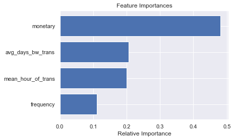

```python
# plot feature importance
features = X.columns
importances =  classifier_RF.feature_importances_
indices = np.argsort(importances)

plt.title('Feature Importances')
plt.barh(range(len(indices)), importances[indices], align='center')
plt.yticks(range(len(indices)), [features[i] for i in indices])
plt.xlabel('Relative Importance')
plt.show()
```

It is not surprising that monetary is our top most important feature in predicting customer churn. As monetary and frequency are highly correlated, RF treats frequency as the least important.

```python
# Confusion matrix

predicted = classifier_RF.predict(X_test)

cfm =metrics.confusion_matrix(y_test,predicted)
print(cfm)
```

```
[[1661  334]
 [ 546  330]]
```

```python
print(metrics.classification_report(y_test, predicted))
```

```
              precision    recall  f1-score   support

           0       0.75      0.83      0.79      1995
           1       0.50      0.38      0.43       876

    accuracy                           0.69      2871
   macro avg       0.62      0.60      0.61      2871
weighted avg       0.67      0.69      0.68      2871
```